# Predicting Quality of Exercise with Machine Learning

P. Lichtenstein

Friday, August 21, 2015

In a novel study of human activity recognition, Vellos et al., (2013) investigate whether qualitative information regarding an activity can be extracted from accelerometer data and transmitted to users as performance-enhancing feedback. While most previous studies have focused on quantitative information with respect to human activity recognition, Vellos et al., demonstrate that qualitative information - i.e., how well a weight lifting exercise was performed – can aslo be successfully modeled using accelermoter data. For the present project, I build a machine learning algorithm to predict the quality of exercise based on a number of variables from the accelerometer data.

I begin by partitioning the data into training and testing sets using a 75/25 percent split. I then implement a random forest algorithm using the caret package in R. For in-sample error estimation, I specify the use of out-of-bag (oob) error estimation. In OOB error estimation, around one third of the sample cases is excluded from tree construction and then used to create a test set classification.

Next I used the test data to obtain an expected out of sample error using the predict function in caret. I compare the prediction results to the actual classifications, and produce a finding of 99.3 percent correct with a 0.7 percent out-of-sample error expectation.

The following confusion matrix summarizes the results.

```
## Confusion Matrix and Statistics
##
##           Reference
## Prediction    A    B    C    D    E
##          A 1393    7    0    0    0
##          B    1  939   10    0    0
##          C    1    3  842    3    1
##          D    0    0    3  800    2
##          E    0    0    0    1  898
##
## Overall Statistics
##
##                Accuracy : 0.9935
##                  95% CI : (0.9908, 0.9955)
##     No Information Rate : 0.2845
##     P-Value [Acc > NIR] : < 2.2e-16
##
##                   Kappa : 0.9917
##  Mcnemar's Test P-Value : NA
##
## Statistics by Class:
##
##                      Class: A Class: B Class: C Class: D Class: E
## Sensitivity            0.9986   0.9895   0.9848   0.9950   0.9967
## Specificity            0.9980   0.9972   0.9980   0.9988   0.9998
## Pos Pred Value         0.9950   0.9884   0.9906   0.9938   0.9989
## Neg Pred Value         0.9994   0.9975   0.9968   0.9990   0.9993
## Prevalence             0.2845   0.1935   0.1743   0.1639   0.1837
## Detection Rate         0.2841   0.1915   0.1717   0.1631   0.1831
## Detection Prevalence   0.2855   0.1937   0.1733   0.1642   0.1833
## Balanced Accuracy      0.9983   0.9933   0.9914   0.9969   0.9982
```

The following confusion matrix summarizes the results.

```
## Confusion Matrix and Statistics
##
##           Reference
## Prediction    A    B    C    D    E
##          A 1393    7    0    0    0
##          B    1  939   10    0    0
##          C    1    3  842    3    1
##          D    0    0    3  800    2
##          E    0    0    0    1  898
##
## Overall Statistics
##
##                Accuracy : 0.9935
##                  95% CI : (0.9908, 0.9955)
##     No Information Rate : 0.2845
##     P-Value [Acc > NIR] : < 2.2e-16
##
##                   Kappa : 0.9917
##  Mcnemar's Test P-Value : NA
##
## Statistics by Class:
##
##                      Class: A Class: B Class: C Class: D Class: E
## Sensitivity            0.9986   0.9895   0.9848   0.9950   0.9967
## Specificity            0.9980   0.9972   0.9980   0.9988   0.9998
## Pos Pred Value         0.9950   0.9884   0.9906   0.9938   0.9989
## Neg Pred Value         0.9994   0.9975   0.9968   0.9990   0.9993
## Prevalence             0.2845   0.1935   0.1743   0.1639   0.1837
## Detection Rate         0.2841   0.1915   0.1717   0.1631   0.1831
## Detection Prevalence   0.2855   0.1937   0.1733   0.1642   0.1833
## Balanced Accuracy      0.9983   0.9933   0.9914   0.9969   0.9982
```

The following plot shows the relationship between estimate performance and the tuning parameters.

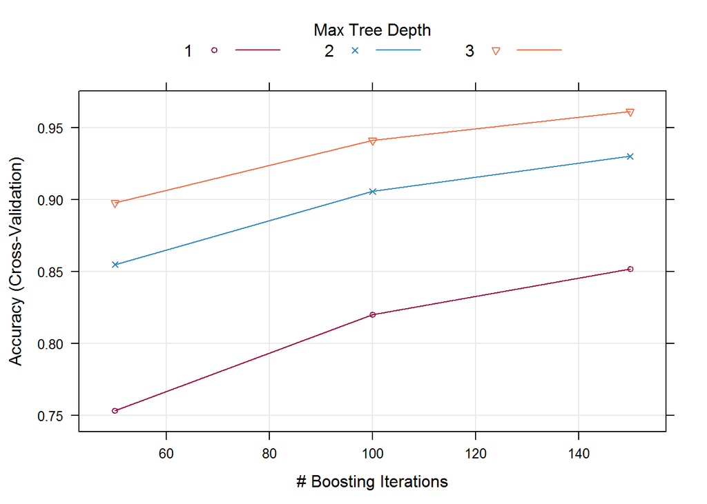

The following confusion matrix summarizes the results.

```
## Confusion Matrix and Statistics
##
##           Reference
## Prediction    A    B    C    D    E
##          A 1370   39    0    0    0
##          B   16  881   27    4   11
##          C    7   27  817   18    8
##          D    2    1   10  779    7
##          E    0    1    1    3  875
##
## Overall Statistics
##
##                Accuracy : 0.9629
##                  95% CI : (0.9572, 0.968)
##     No Information Rate : 0.2845
##     P-Value [Acc > NIR] : < 2.2e-16
##
##                   Kappa : 0.953
##  Mcnemar's Test P-Value : NA
##
## Statistics by Class:
##
##                      Class: A Class: B Class: C Class: D Class: E
## Sensitivity            0.9821   0.9283   0.9556   0.9689   0.9711
## Specificity            0.9889   0.9853   0.9852   0.9951   0.9988
## Pos Pred Value         0.9723   0.9382   0.9316   0.9750   0.9943
## Neg Pred Value         0.9928   0.9828   0.9906   0.9939   0.9935
## Prevalence             0.2845   0.1935   0.1743   0.1639   0.1837
## Detection Rate         0.2794   0.1796   0.1666   0.1588   0.1784
## Detection Prevalence   0.2873   0.1915   0.1788   0.1629   0.1794
## Balanced Accuracy      0.9855   0.9568   0.9704   0.9820   0.9849
```

Reference:

Velloso, E.; Bulling, A.; Gellersen, H.; Ugulino, W.; Fuks, H. Qualitative Activity Recognition of Weight Lifting Exercises. Proceedings of 4th International Conference in Cooperation with SIGCHI (Augmented Human ’13). Stuttgart, Germany: ACM SIGCHI, 2013.